# report

Histogramm  
Histogramm - interval - August 17, 2016

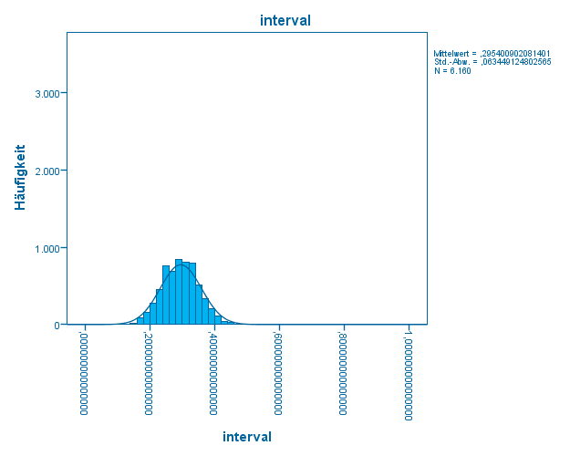

Histogramm  
Histogramm - parson - August 17, 2016

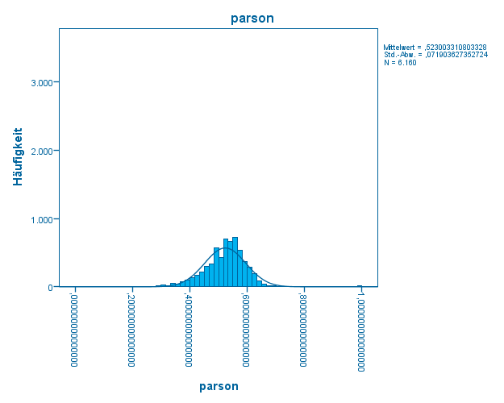

Histogramm  
Histogramm - ju - August 17, 2016

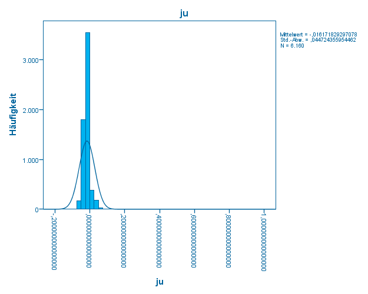


Log  
Log - Log - August 17, 2016

FREQUENCIES VARIABLES=ms gar interval parson ju  
/FORMAT=NOTABLE  
/PERCENTILES=5.0 10.0 25.0 50.0 75.0 90.0 95.0  
/STATISTICS=STDDEV VARIANCE RANGE MINIMUM MAXIMUM SEMEAN MEAN MEDIAN  
/HISTOGRAM NORMAL  
/ORDER=ANALYSIS.

Log  
Log - Log - August 17, 2016

FREQUENCIES VARIABLES=ms_ju gar_ju interval_ju parson_ju  
/FORMAT=NOTABLE  
/PERCENTILES=5 10 25 50 75 90 95  
/STATISTICS=STDDEV VARIANCE RANGE MINIMUM MAXIMUM SEMEAN MEAN MEDIAN MODE SUM SKEWNESS SESKEW  
KURTOSIS SEKURT  
/GROUPED=ms_ju gar_ju interval_ju parson_ju  
/HISTOGRAM NORMAL  
/ORDER=ANALYSIS.

Häufigkeiten  
Häufigkeiten - Anmerkungen - August 17, 2016

AnmerkungenAnmerkungen, Tabelle, 0 Stufen von Spaltenüberschriften und 2 Stufen von Zeilenüberschriften, Tabelle mit 3 Spalten und 13 Zeilen

| Ausgabe erstellt |  | 17-AUG-2016 18:04:08 |
| --- | --- | --- |
| Kommentare |  |  |
| Eingabe | Aktiver Datensatz | DataSet1 |
|  | Filter | <keine> |
|  | Gewichtung | <keine> |
|  | Aufgeteilte Datei | <keine> |
|  | Anzahl der Zeilen in der Arbeitsdatei | 6160 |
| Behandlung fehlender Werte | Definition von fehlenden Werten | Benutzerdefinierte fehlende Werte werden als fehlend behandelt. |
|  | Verwendete Fälle | Statistik basiert auf allen Fällen mit gültigen Daten. |
| Syntax |  | FREQUENCIES VARIABLES=ms_ju gar_ju interval_ju parson_ju /FORMAT=NOTABLE /PERCENTILES=5 10 25 50 75 90 95 /STATISTICS=STDDEV VARIANCE RANGE MINIMUM MAXIMUM SEMEAN MEAN MEDIAN MODE SUM SKEWNESS SESKEW … |
| Ressourcen | Prozessorzeit | 00:00:01,37 |
|  | Verstrichene Zeit | 00:00:01,21 |

Häufigkeiten  
Häufigkeiten - Statistiken - August 17, 2016

StatistikenStatistiken, Tabelle, 1 Stufen von Spaltenüberschriften und 2 Stufen von Zeilenüberschriften, Tabelle mit 6 Spalten und 28 Zeilen

|  |  | ms_ju | gar_ju | interval_ju | parson_ju |
| --- | --- | --- | --- | --- | --- |
| N | Gültig | 6160 | 6160 | 6160 | 6160 |
|  | Fehlend | 0 | 0 | 0 | 0 |
| Mittelwert |  | ,411882528000000 | ,399090652000000 | ,311572731000000 | ,539175140000000 |
| Standardfehler des Mittelwertes |  | ,002131637670000 | ,001207676370000 | ,000717039631000 | ,000900792512000 |
| Median |  | ,426590391000000<sup>a</sup> | ,402422220000000<sup>a</sup> | ,312690049000000<sup>a</sup> | ,547705330000000<sup>a</sup> |
| Modus |  | ,164497407000000<sup>b</sup> | ,520415025000000 | ,345528453000000 | ,510869570000000 |
| Standardabweichung |  | ,167303006000000 | ,094785286300000 | ,056277334100000 | ,070699301500000 |
| Varianz |  | ,028 | ,009 | ,003 | ,005 |
| Schiefe |  | -,197 | -,418 | -,192 | -1,213 |
| Standardfehler der Schiefe |  | ,031 | ,031 | ,031 | ,031 |
| Kurtosis |  | -1,035 | ,795 | ,835 | 5,161 |
| Standardfehler der Kurtosis |  | ,062 | ,062 | ,062 | ,062 |
| Spannweite |  | ,771256287000000 | ,721203955000000 | ,509468703000000 | ,775730571000000 |
| Minimum |  | ,000930606130000 | ,002432814440000 | ,012997770000000 | ,012997770000000 |
| Maximum |  | ,772186893000000 | ,723636769000000 | ,522466473000000 | ,788728341000000 |
| Summe |  | 2537,196369999999700 | 2458,398417000000000 | 1919,288024999999800 | 3321,318863000000000 |
| Perzentile | 5 | ,136423566000000<sup>c</sup> | ,244843972000000<sup>c</sup> | ,222327780000000<sup>c</sup> | ,415078928000000<sup>c</sup> |
|  | 10 | ,177192602000000 | ,283051496000000 | ,241791945000000 | ,450803203000000 |
|  | 25 | ,270726743000000 | ,339355949000000 | ,273470330000000 | ,502010069000000 |
|  | 50 | ,426590391000000 | ,402422220000000 | ,312690049000000 | ,547705330000000 |
|  | 75 | ,555629967000000 | ,464045226000000 | ,349858229000000 | ,584072710000000 |
|  | 90 | ,617973762000000 | ,516130546000000 | ,382136405000000 | ,618489519000000 |
|  | 95 | ,651274732000000 | ,543891353000000 | ,402151598000000 | ,637045522000000 |

a. Aus gruppierten Daten berechnet  
b. Mehrere Modi vorhanden. Der kleinste Wert wird angezeigt.  
c. Perzentile werden aus gruppierten Daten berechnet.

Histogramm  
Histogramm - ms_ju - August 17, 2016

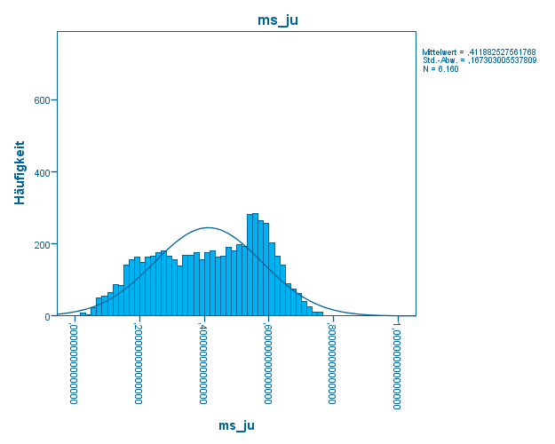